# Group F Final Project: Air Travel Analysis

#### Regression

```r
airlineRegress <- lm(formula=ArrDel15~Reporting_Airline, data=kennedySelected)
summary(airlineRegress)
```

```
##
## Call:
## lm(formula = ArrDel15 ~ Reporting_Airline, data = kennedySelected)
##
## Residuals:
##     Min      1Q  Median      3Q     Max
## -0.2817 -0.2028 -0.1916 -0.1574  0.9231
##
## Coefficients:
##                     Estimate Std. Error t value Pr(>|t|)
## (Intercept)          0.12081    0.01672   7.225 5.21e-13 ***
## Reporting_AirlineAA  0.06032    0.01784   3.382 0.000721 ***
## Reporting_AirlineAS -0.04388    0.04915  -0.893 0.371952
## Reporting_AirlineB6  0.16084    0.01766   9.109  < 2e-16 ***
## Reporting_AirlineDL  0.08198    0.01756   4.670 3.04e-06 ***
## Reporting_AirlineUA  0.03656    0.02276   1.607 0.108161
## Reporting_AirlineYX  0.07078    0.02154   3.286 0.001020 **
## ---
## Signif. codes:  0 '***' 0.001 '**' 0.01 '*' 0.05 '.' 0.1 ' ' 1
##
## Residual standard error: 0.4082 on 17567 degrees of freedom
##   (495 observations deleted due to missingness)
## Multiple R-squared:  0.01294,    Adjusted R-squared:  0.0126
## F-statistic: 38.38 on 6 and 17567 DF,  p-value: < 2.2e-16
```

```r
sum(kennedySelected$Cancelled)
```

```
## [1] 455
```

```r
airlineRegressCan <- lm(formula=Cancelled~Reporting_Airline, data=kennedySelected)
summary(airlineRegressCan)
```

```
##
## Call:
## lm(formula = Cancelled ~ Reporting_Airline, data = kennedySelected)
##
## Residuals:
##      Min       1Q   Median       3Q      Max
## -0.04921 -0.02849 -0.02340 -0.01954  0.98734
##
## Coefficients:
##                      Estimate Std. Error t value Pr(>|t|)
## (Intercept)          0.049206   0.006238   7.888 3.24e-15 ***
## Reporting_AirlineAA -0.020718   0.006664  -3.109  0.00188 **
## Reporting_AirlineAS -0.036548   0.018688  -1.956  0.05051 .
## Reporting_AirlineB6 -0.025806   0.006598  -3.911 9.23e-05 ***
## Reporting_AirlineDL -0.029671   0.006561  -4.523 6.15e-06 ***
## Reporting_AirlineUA -0.016103   0.008528  -1.888  0.05901 .
## Reporting_AirlineYX -0.015164   0.008062  -1.881  0.06000 .
## ---
## Signif. codes:  0 '***' 0.001 '**' 0.01 '*' 0.05 '.' 0.1 ' ' 1
##
## Residual standard error: 0.1566 on 18062 degrees of freedom
## Multiple R-squared:  0.001691,   Adjusted R-squared:  0.00136
## F-statistic:   5.1 on 6 and 18062 DF,  p-value: 3.051e-05
```

```r
destRegress <- lm(formula=ArrDel15~Dest, data=kennedySelected)
summary(destRegress)
```

```
##
## Call:
## lm(formula = ArrDel15 ~ Dest, data = kennedySelected)
##
## Residuals:
##     Min      1Q  Median      3Q     Max
## -0.3043 -0.2021 -0.2021 -0.1882  0.8118
##
## Coefficients:
##              Estimate Std. Error t value Pr(>|t|)
## (Intercept)  0.238256   0.007536  31.618  < 2e-16 ***
## DestDEN      0.066048   0.014999   4.403 1.07e-05 ***
## DestDFW     -0.009484   0.012152  -0.780    0.435
## DestLAX     -0.036170   0.008641  -4.186 2.85e-05 ***
## DestORD     -0.050071   0.011300  -4.431 9.43e-06 ***
## ---
## Signif. codes:  0 '***' 0.001 '**' 0.01 '*' 0.05 '.' 0.1 ' ' 1
##
## Residual standard error: 0.4099 on 17569 degrees of freedom
##   (495 observations deleted due to missingness)
## Multiple R-squared:  0.004448,   Adjusted R-squared:  0.004221
## F-statistic: 19.62 on 4 and 17569 DF,  p-value: 3.94e-16
```

```r
sum(kennedySelected$Cancelled)
```

```
## [1] 455
```

```r
airlineRegressDest <- lm(formula=Cancelled~Dest, data=kennedySelected)
summary(airlineRegressDest)
```

```
##
## Call:
## lm(formula = Cancelled ~ Dest, data = kennedySelected)
##
## Residuals:
##      Min       1Q   Median       3Q      Max
## -0.04691 -0.03282 -0.01867 -0.01867  0.98133
##
## Coefficients:
##              Estimate Std. Error t value Pr(>|t|)
## (Intercept)  0.020165   0.002843   7.093 1.36e-12 ***
## DestDEN      0.012653   0.005629   2.248  0.02460 *
## DestDFW      0.013047   0.004558   2.863  0.00421 **
## DestLAX     -0.001494   0.003261  -0.458  0.64681
## DestORD      0.026747   0.004229   6.324 2.61e-10 ***
## ---
## Signif. codes:  0 '***' 0.001 '**' 0.01 '*' 0.05 '.' 0.1 ' ' 1
##
## Residual standard error: 0.1564 on 18064 degrees of freedom
## Multiple R-squared:  0.00416,    Adjusted R-squared:  0.003939
## F-statistic: 18.86 on 4 and 18064 DF,  p-value: 1.723e-15
```

Because LAX wasn’t the front runner for the arriving on time analysis, we wanted to dive deeper into which variables are most likely to cause delays in order to better predict delays for our customers. We again used the ArrDel15 as our dependent variable, but now we used multiple regression to have the day of the week, month, the departure delay time, if there was a weather delay, and if there was a carrier delay. We found that Weather delays and Carrier delays were not statistically significant (p value was too high). We then reran the multiple regression with just the significant variables to get the below output. We can see from the regression that the later in the week (Monday=1, Sunday=7) a flight is, the more likely it would arrive late. Conversely, the later in the year (January=1, December=12) a flight is, the less likely it would arrive late. Departure Delay is something that is significant, to be expected, but that is something that is a little out of our control. From this, we can encourage our customers to fly on a weekday and later on in the year to get the best chance at being not delayed.

```r
multRegress = lm(formula = ArrDel15 ~ DayOfWeek + Month + DepDelay, data=kennedySelected)
summary(multRegress)
```

```
##
## Call:
## lm(formula = ArrDel15 ~ DayOfWeek + Month + DepDelay, data = kennedySelected)
##
## Residuals:
##     Min      1Q  Median      3Q     Max
## -3.6637 -0.1633 -0.1371 -0.1062  0.9132
##
## Coefficients:
##               Estimate Std. Error t value Pr(>|t|)
## (Intercept)  1.646e-01  7.627e-03  21.577  < 2e-16 ***
## DayOfWeek    4.505e-03  1.316e-03   3.423  0.00062 ***
## Month       -4.669e-03  7.657e-04  -6.098  1.1e-09 ***
## DepDelay     3.843e-03  4.733e-05  81.199  < 2e-16 ***
## ---
## Signif. codes:  0 '***' 0.001 '**' 0.01 '*' 0.05 '.' 0.1 ' ' 1
##
## Residual standard error: 0.3492 on 17570 degrees of freedom
##   (495 observations deleted due to missingness)
## Multiple R-squared:  0.2774, Adjusted R-squared:  0.2773
## F-statistic:  2249 on 3 and 17570 DF,  p-value: < 2.2e-16
```

#### Map Analysis Support

To further back our findings with the regressions, we wanted to look at the data in a visual format. Given that flight data is geographic by nature, we decided to do a deep dive into maps to incur more conclusions

```r
library(ggmap)
library(ggplot2)

# Merge State Data
kennedySelected$DestStateMap<- kennedySelected$DestState
kennedySelected$DestStateMap <- gsub ("CA", "california",(kennedySelected$DestStateMap))
kennedySelected$DestStateMap <- gsub ("TX", "texas", (kennedySelected$DestStateMap))
kennedySelected$DestStateMap <- gsub ("CO", "colorado", (kennedySelected$DestStateMap))
kennedySelected$DestStateMap <- gsub ("IL", "illinois", (kennedySelected$DestStateMap))
kennedySelected$DestStateMap <- gsub ("GA", "georgia", (kennedySelected$DestStateMap))
us <- map_data("state")
jfkWithGeom <- merge(kennedySelected,us,by.x="DestStateMap", by.y="region")
jfkWithGeom <- jfkWithGeom %>% arrange(order)
```

Next, we created airline specific data frames to be able to run cancellation rate calculations, delay rate calculations, and flight distribution calculations.

```r
#Create aesthetic data frames

####################
#Airline Data
###################

unitedDF <- kennedySelected %>%filter(Reporting_Airline == "UA")
deltaDF <- kennedySelected %>%filter(Reporting_Airline == "DL")
endeavorDF <- kennedySelected %>%filter(Reporting_Airline == "9E")
americanDF <- kennedySelected %>%filter(Reporting_Airline == "AA")
alaskaDF <- kennedySelected %>%filter(Reporting_Airline == "AS")
jetBlueDF <- kennedySelected %>%filter(Reporting_Airline == "B6")

#Flight number count
unitedCount <- nrow(unitedDF)
deltaCount<- nrow(deltaDF)
endeavorCount<- nrow(endeavorDF)
americanCount <- nrow(americanDF)
alaskaCount <- nrow(alaskaDF)
jetBlueCount <- nrow(jetBlueDF)

#Delayed Flights to 0
kennedySelected["ArrDel15"][is.na(kennedySelected ["ArrDel15"])] <- 0

# Percentage of flights delayed
unitedPctDelayed <- sum(unitedDF$ArrDel15 == 1)/unitedCount
deltaPctDelayed <- sum(deltaDF$ArrDel15 == 1)/deltaCount
endeavorPctDelayed <- sum(endeavorDF$ArrDel15 == 1)/endeavorCount
americanPctDelayed <- sum(americanDF$ArrDel15 == 1)/americanCount
alaskaPctDelayed <- sum(alaskaDF$ArrDel15 == 1)/alaskaCount
jetBluePctDelayed <- sum(jetBlueDF$ArrDel15 == 1)/jetBlueCount

#Percentage of flights cancelled
unitedPctCancelled <- sum(unitedDF$Cancelled == 1)/unitedCount
deltaPctCancelled <- sum(deltaDF$Cancelled == 1)/deltaCount
endeavorPctCancelled <- sum(endeavorDF$Cancelled == 1)/endeavorCount
americanPctCancelled <- sum(americanDF$Cancelled == 1)/americanCount
alaskaPctCancelled <- sum(alaskaDF$Cancelled == 1)/alaskaCount
jetBluePctCancelled <- sum(jetBlueDF$Cancelled == 1)/jetBlueCount

#Percentage of XX airline to respective airport
unitedPctToLAX <- sum(unitedDF$Dest == "LAX")/unitedCount
deltaPctToLAX <- sum(deltaDF$Dest == "LAX")/deltaCount
endeavorPctToLAX <- sum(endeavorDF$Dest == "LAX")/endeavorCount
americanPctToLAX <- sum(americanDF$Dest == "LAX")/americanCount
alaskaPctToLAX <- sum(alaskaDF$Dest == "LAX")/alaskaCount
jetBluePctToLAX <- sum(jetBlueDF$Dest == "LAX")/jetBlueCount

unitedPctToATL <- sum(unitedDF$Dest == "ATL")/unitedCount
deltaPctToATL <- sum(deltaDF$Dest == "ATL")/deltaCount
endeavorPctToATL <- sum(endeavorDF$Dest == "ATL")/endeavorCount
americanPctToATL <- sum(americanDF$Dest == "ATL")/americanCount
alaskaPctToATL <- sum(alaskaDF$Dest == "ATL")/alaskaCount
jetBluePctToATL <- sum(jetBlueDF$Dest == "ATL")/jetBlueCount

unitedPctToORD <- sum(unitedDF$Dest == "ORD")/unitedCount
deltaPctToORD <- sum(deltaDF$Dest == "ORD")/deltaCount
endeavorPctToORD <- sum(endeavorDF$Dest == "ORD")/endeavorCount
americanPctToORD <- sum(americanDF$Dest == "ORD")/americanCount
alaskaPctToORD <- sum(alaskaDF$Dest == "ORD")/alaskaCount
jetBluePctToORD <- sum(jetBlueDF$Dest == "ORD")/jetBlueCount

unitedPctToDFW <- sum(unitedDF$Dest == "DFW")/unitedCount
deltaPctToDFW <- sum(deltaDF$Dest == "DFW")/deltaCount
endeavorPctToDFW <- sum(endeavorDF$Dest == "DFW")/endeavorCount
americanPctToDFW <- sum(americanDF$Dest == "DFW")/americanCount
alaskaPctToDFW <- sum(alaskaDF$Dest == "DFW")/alaskaCount
jetBluePctToDFW <- sum(jetBlueDF$Dest == "DFW")/jetBlueCount

unitedPctToDEN <- sum(unitedDF$Dest == "DEN")/unitedCount
deltaPctToDEN <- sum(deltaDF$Dest == "DEN")/deltaCount
endeavorPctToDEN <- sum(endeavorDF$Dest == "DEN")/endeavorCount
americanPctToDEN <- sum(americanDF$Dest == "DEN")/americanCount
alaskaPctToDEN <- sum(alaskaDF$Dest == "DEN")/alaskaCount
jetBluePctToDEN <- sum(jetBlueDF$Dest == "DEN")/jetBlueCount

#Final Data Frame combining everything
airlineNames <- c( "United Airlines", "Delta", "Endeavor Air", "American Airlines",
                   "Alaska Airlines", "Jet Blue")
airlineFlightCount <- c(unitedCount, deltaCount, endeavorCount, americanCount,
                        alaskaCount, jetBlueCount)
pctDelayed <- c(unitedPctDelayed, deltaPctDelayed, endeavorPctDelayed, americanPctDelayed,
                alaskaPctDelayed,jetBluePctDelayed)
pctCancelled <- c(unitedPctCancelled, deltaPctCancelled, endeavorPctCancelled,
                  americanPctCancelled,alaskaPctCancelled,jetBluePctCancelled)
pctOfAirlineToLAX <- c(unitedPctToLAX, deltaPctToLAX, endeavorPctToLAX, americanPctToLAX,
                       alaskaPctToLAX, jetBluePctToLAX)
pctOfAirlineToATL <- c(unitedPctToATL, deltaPctToATL, endeavorPctToATL, americanPctToATL,
                       alaskaPctToATL, jetBluePctToATL)
pctOfAirlineToORD <- c(unitedPctToORD, deltaPctToORD, endeavorPctToORD, americanPctToORD,
                       alaskaPctToORD, jetBluePctToORD)
pctOfAirlineToDFW <- c(unitedPctToDFW, deltaPctToDFW, endeavorPctToDFW, americanPctToDFW,
                       alaskaPctToDFW, jetBluePctToDFW)
pctOfAirlineToDEN <- c(unitedPctToDEN, deltaPctToDEN, endeavorPctToDEN, americanPctToDEN,
                       alaskaPctToDEN, jetBluePctToDEN)
airlineDF <- data.frame(airlineNames, airlineFlightCount, pctDelayed, pctCancelled,
                        pctOfAirlineToLAX, pctOfAirlineToATL, pctOfAirlineToORD,
                        pctOfAirlineToDFW, pctOfAirlineToDEN)
```

Next, we created Airport location specific data frames. These calculations were created more with the intention of being able to aesthetically manipulate the maps, as opposed to drawing conclusions.

```r
####################
#Airport Data
###################

laxPoint <- geom_point(aes(x=-118.410042, y=33.942791))
atlPoint <- geom_point(aes(x= -84.386330, y=33.753746))
ordPoint <- geom_point(aes(x=   -87.904724, y=41.978611))
denPoint <- geom_point(aes(x=-104.673828, y=39.849312))
dfwPoint <- geom_point(aes(x=   -96.808891, y=32.779167))

laxDF <- kennedySelected %>%filter(Dest == "LAX")
laxCount <- nrow(laxDF)
atlDF <- kennedySelected %>%filter(Dest == "ATL")
atlCount <- nrow(atlDF)
ordDF <- kennedySelected %>% filter(Dest == "ORD")
ordCount <- nrow(ordDF)
dfwDF <- kennedySelected %>%filter(Dest == "DFW")
dfwCount <- nrow(dfwDF)
denDF <- kennedySelected %>%filter(Dest == "DEN")
denCount <- nrow(denDF)

airportNames <- c("LAX", "ATL", "ORD", "DEN", "DFW")
longitudeX <- c(-118.410042, -84.386330, -87.904724, -104.673828, -96.808891)
latitudeY <- c(33.942791, 33.753746, 41.978611, 39.849312, 32.779167)
airportCounts <- c(laxCount, atlCount, ordCount, dfwCount, denCount)
airportDF <- data.frame(airportNames, longitudeX, latitudeY, airportCounts)
```

With all of our necessary data organized and transformed, we are ready to make the maps. We started by creating a base raster map. We mapped the states and airport locations.

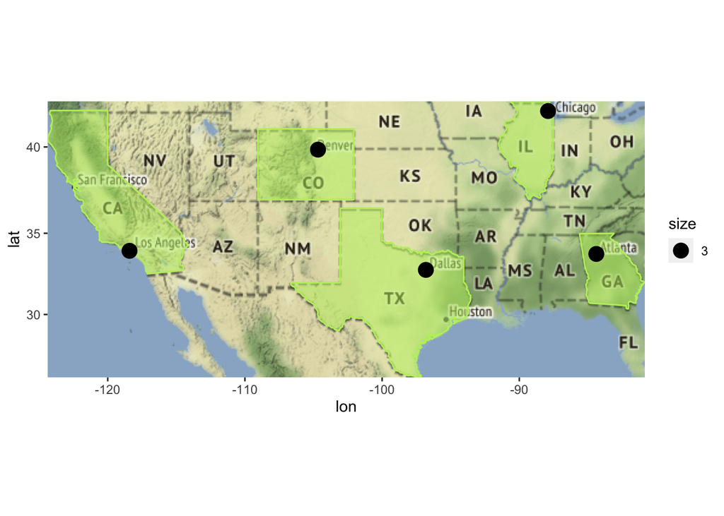

```r
#######################################
#Create the Maps with the data frames
######################################


# put a map image behind the visualization
bb <- c(left = min(jfkWithGeom$long),
        bottom = min(jfkWithGeom$lat),
        right = max(jfkWithGeom$long),
        top = max(jfkWithGeom$lat))

# show the map
map <- get_stamenmap(bbox = bb, zoom = 4)
# Add relevant state outlines on map
jfkWithGeomMap <- ggmap(map) +
  geom_polygon(data = jfkWithGeom, alpha = 0.5,
               color = "darkolivegreen2", fill = "darkolivegreen2",
               aes(x=long, y= lat, group=group))
jfkWithGeomMap + geom_point(data = airportDF, color = "black",
                           aes(x=longitudeX, y=latitudeY, size = 3))
```

Now that we have our base map, we can start to plot our data points in an insightful way. We first assesed our airports on the amount of traffic they receive from incoming flights that departed from JFK.

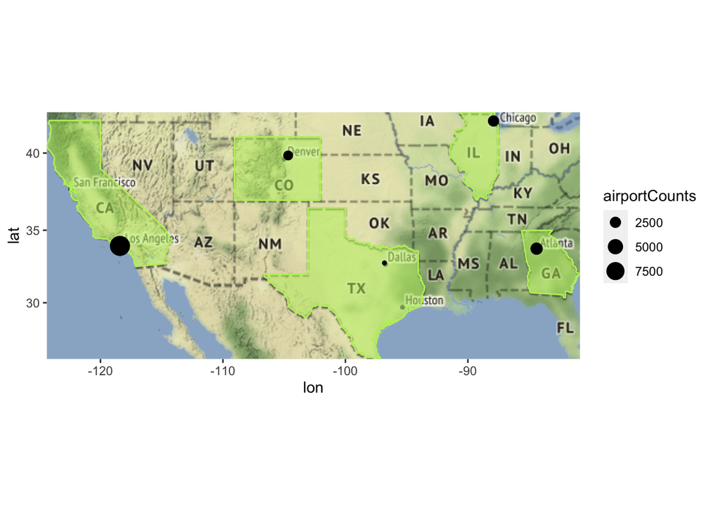

```r
#AIRPORT SIZES DEPENDENT UPON NUMBER OF TRIPS RUN THERE

jfkWithGeomMap + geom_point(data = airportDF, color = "black",
                           aes(x=longitudeX, y=latitudeY, size = airportCounts))
```

Based on this information, we were ready to then look at airline specific data and decide which of our 6 carriers was the best choice. We began by examining the distribution of their flight destinations. In order to do this, we had to organize the geographic location of the airports into a data frame. We also had to draw lines, with size indicating the distribution of the flights.

```r
#Data Organization

#ROUTES BY AIRLINE
LAX <- c(-118.410042,33.942791)
ATL <- c(-84.386330,33.753746)
ORD <- c(-87.904724,41.978611)
DEN <- c(-104.673828,39.849312)
DFW <- c(-96.808891,32.779167)
JFK <- c(-73.780968,40.641766)

airportLongLat <- rbind(LAX, ATL, ORD, DEN, DFW, JFK) %>%
  as.data.frame()
colnames(airportLongLat) <- c("long","lat")

library(geosphere)
```

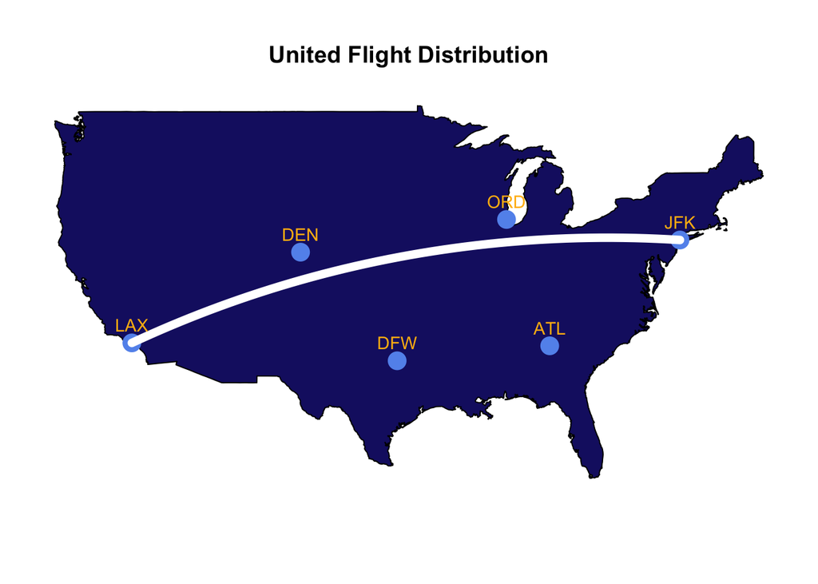

```r
#UNITED
maps::map('usa',
          col="midnightblue", fill=TRUE)
points(x=airportLongLat$long, y=airportLongLat$lat, col="cornflowerblue", cex=3, pch=20)
interUnitedLAX <- gcIntermediate(JFK, LAX, n=50, addStartEnd=TRUE, breakAtDateLine=F)
lines(interUnitedLAX, col="white", lwd=7)
text(rownames(airportLongLat), x=airportLongLat$long, y=airportLongLat$lat,
           col="darkgoldenrod1", cex=.9, pos=3)
title("United Flight Distribution", cex=3)
```

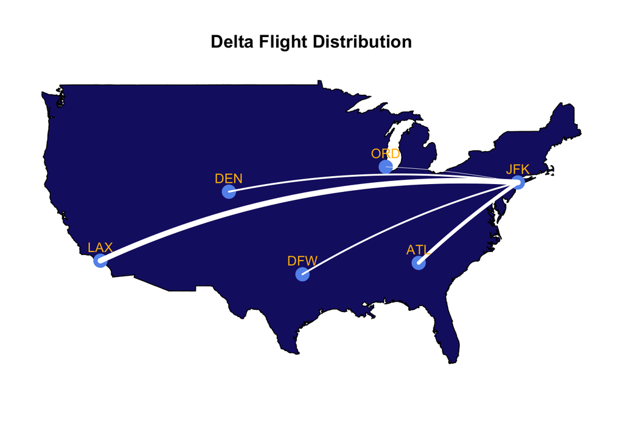

```r
#DELTA
maps::map('usa',
          col="midnightblue", fill=TRUE)
points(x=airportLongLat$long, y=airportLongLat$lat, col="cornflowerblue", cex=3, pch=20)
interDeltaLAX <- gcIntermediate(JFK, LAX, n=50, addStartEnd=TRUE, breakAtDateLine=F)
lines(interDeltaLAX, col="white", lwd=6)
interDeltaORD <- gcIntermediate(JFK, ORD, n=50, addStartEnd=TRUE, breakAtDateLine=F)
lines(interDeltaORD, col="white", lwd=0.5)
interDeltaDFW <- gcIntermediate(JFK, DFW, n=50, addStartEnd=TRUE, breakAtDateLine=F)
lines(interDeltaDFW, col="white", lwd=2)
interDeltaATL <- gcIntermediate(JFK, ATL, n=50, addStartEnd=TRUE, breakAtDateLine=F)
lines(interDeltaATL, col="white", lwd=4)
interDeltaDEN <- gcIntermediate(JFK, DEN, n=50, addStartEnd=TRUE, breakAtDateLine=F)
lines(interDeltaDEN, col="white", lwd=2)
text(rownames(airportLongLat), x=airportLongLat$long, y=airportLongLat$lat,
     col="darkgoldenrod1", cex=.9, pos=3)
title("Delta Flight Distribution", cex=3)
```

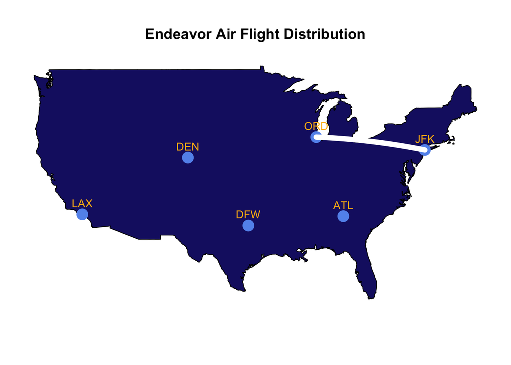

```r
#Endeavor
maps::map('usa',
          col="midnightblue", fill=TRUE)
points(x=airportLongLat$long, y=airportLongLat$lat, col="cornflowerblue", cex=3, pch=20)
interEndeavorORD <- gcIntermediate(JFK, ORD, n=50, addStartEnd=TRUE, breakAtDateLine=F)
lines(interEndeavorORD, col="white", lwd=7)
text(rownames(airportLongLat), x=airportLongLat$long, y=airportLongLat$lat,
     col="darkgoldenrod1", cex=.9, pos=3)
title("Endeavor Air Flight Distribution", cex=3)
```

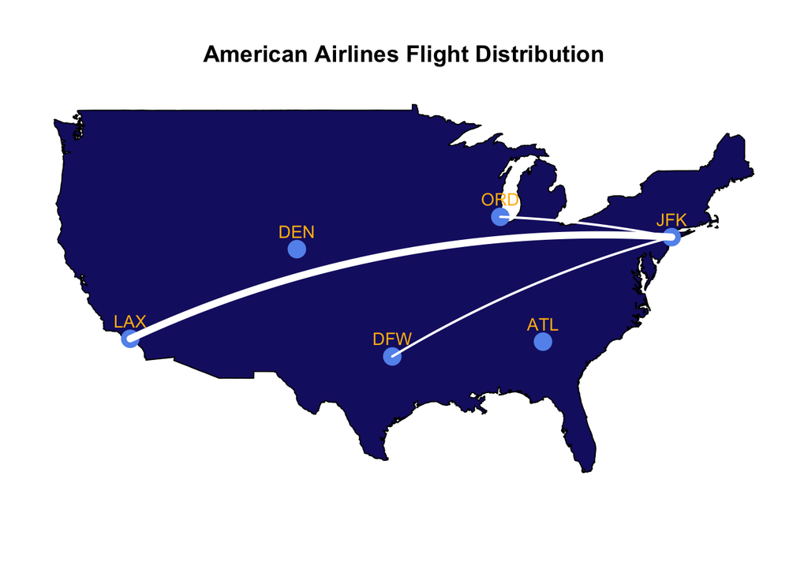

```r
#American
maps::map('usa',
          col="midnightblue", fill=TRUE)
points(x=airportLongLat$long, y=airportLongLat$lat, col="cornflowerblue", cex=3, pch=20)
interAmericanLAX <- gcIntermediate(JFK, LAX, n=50, addStartEnd=TRUE, breakAtDateLine=F)
lines(interAmericanLAX, col="white", lwd=6)
interAmericanORD <- gcIntermediate(JFK, ORD, n=50, addStartEnd=TRUE, breakAtDateLine=F)
lines(interAmericanORD, col="white", lwd=2)
interAmericanDFW <- gcIntermediate(JFK, DFW, n=50, addStartEnd=TRUE, breakAtDateLine=F)
lines(interAmericanDFW, col="white", lwd=2)
text(rownames(airportLongLat), x=airportLongLat$long, y=airportLongLat$lat,
     col="darkgoldenrod1", cex=.9, pos=3)
title("American Airlines Flight Distribution", cex=3)
```

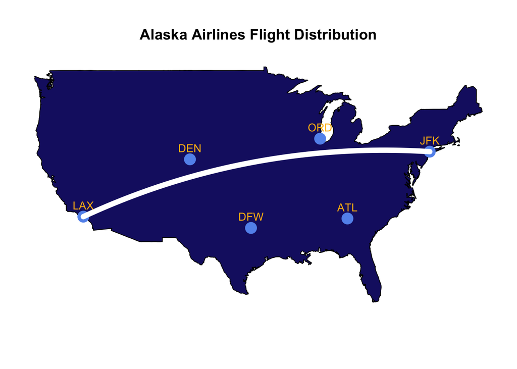

```r
#Alaska
maps::map('usa',
          col="midnightblue", fill=TRUE)
points(x=airportLongLat$long, y=airportLongLat$lat, col="cornflowerblue", cex=3, pch=20)
interAlaskaLAX <- gcIntermediate(JFK, LAX, n=50, addStartEnd=TRUE, breakAtDateLine=F)
lines(interAlaskaLAX, col="white", lwd=7)
text(rownames(airportLongLat), x=airportLongLat$long, y=airportLongLat$lat,
     col="darkgoldenrod1", cex=.9, pos=3)
title("Alaska Airlines Flight Distribution", cex=3)
```

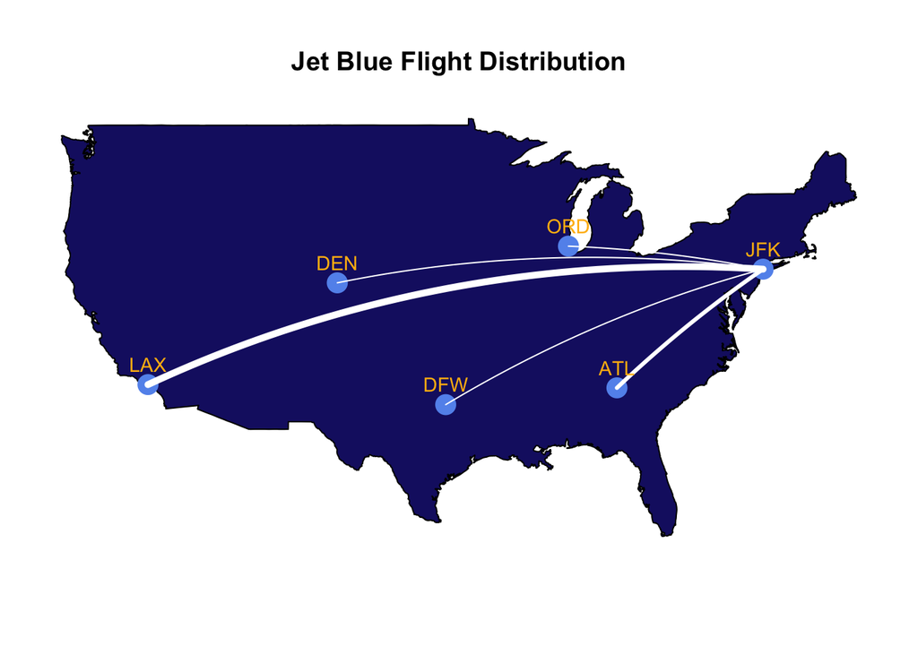

```r
#Jet Blue
maps::map('usa',
          col="midnightblue", fill=TRUE)
points(x=airportLongLat$long, y=airportLongLat$lat, col="cornflowerblue", cex=3, pch=20)
interjetBlueLAX <- gcIntermediate(JFK, LAX, n=50, addStartEnd=TRUE, breakAtDateLine=F)
lines(interjetBlueLAX, col="white", lwd=5)
interjetBlueORD <- gcIntermediate(JFK, ORD, n=50, addStartEnd=TRUE, breakAtDateLine=F)
lines(interjetBlueORD, col="white", lwd=1)
interjetBlueDFW <- gcIntermediate(JFK, DFW, n=50, addStartEnd=TRUE, breakAtDateLine=F)
lines(interjetBlueDFW, col="white", lwd=1)
interjetBlueATL <- gcIntermediate(JFK, ATL, n=50, addStartEnd=TRUE, breakAtDateLine=F)
lines(interjetBlueATL, col="white", lwd=3)
interjetBlueDEN <- gcIntermediate(JFK, DEN, n=50, addStartEnd=TRUE, breakAtDateLine=F)
lines(interjetBlueDEN, col="white", lwd=1)
text(rownames(airportLongLat), x=airportLongLat$long, y=airportLongLat$lat,
     col="darkgoldenrod1", cex=.9, pos=3)
title("Jet Blue Flight Distribution", cex=3)
```

These flight distributions support the conclusions we drew from our initial regressions. Given that LAX was the airport with the most incoming flights and the most airline partnerships, it confirmed our decision to keep LAX our our first destination. That decision allowed us to rule out Endeavor Air as a potential partner. We were also able to rule out American Airlines and Jet Blue as they had more equally distributed flight paths and we wanted to ensure we were partnering with an airline that would invest the most resources into LAX.

This left us to choose between United, Delta, and Alaska Airlines. Combined with the delay and cancellation statistics we saw in our regressions, we felt that the traffic flow map supported our Alaska Decision as they only fly to LAX from JFK. Therefore, we would have plenty of opportunities to re-book when flights inevitably get cancelled or delayed.

#### Heat Maps

Another factor that we chose to display visually was likelihood of a flight to be delayed on any given day of the week. In order to illustrate this in a way that airlines can be compared, we utilized a tiled heat map. The code below contains the process used to determine the unique airlines in our data set, to merge the lookup table containing human-readable airline names, and to clean the data of observations that contained an “NA” in the ArrDel15 observation.

The heatmap was plotted with a tile geometry with the day of the week on the X axis, the airline name on the Y axis, and was filled according to the percentage of flights that arrived at least 15 minutes late. The graph illustrated superior on-time performance by Alaska Airlines with the only exception being Thursday and Friday flights.

```r
####Delays by DoW####

#Count unique airlines in datset
length(unique(kennedySelected$Reporting_Airline))
```

```
## [1] 7
```

```r
#Display unique airline codes in dataset
unique(kennedySelected$Reporting_Airline)
```

```
## [1] "UA" "DL" "YX" "9E" "AA" "AS" "B6"
```

```r
#Create copy of the data and make airline names human readable.
lateDoW <- kennedySelected

#Read in lookup table of Airlines
carrierList <- read_csv("/Users/maddyodenwald/Desktop/L_UNIQUE_CARRIERS.csv")
#Rename "Code" variable in carrierlist dataframe
carrierList$Reporting_Airline <- carrierList$Code

#Rename "Description" variable in carrierList
carrierList$Airline_Name <- carrierList$Description

#Drop unneeded/duplicate variables
carrierList <- carrierList[ ,3:4]

#Merge carrierList with lateDow
lateDoW <- merge(lateDoW, carrierList, by="Reporting_Airline")

#Examine results of merge
head(lateDoW)
```

|  | Reporting_Airline | Year | Month | DayofMonth | DayOfWeek | FlightDate | Flight_Number_Reporting_Airline | Origin | OriginCityName | OriginState | Dest | DestCityName | DestState | DepDelay | DepDel15 | ArrDelay | ArrDel15 | Cancelled | CancellationCode | Diverted | CarrierDelay | WeatherDelay | DestStateMap | Airline_Name |
| --- | --- | --- | --- | --- | --- | --- | --- | --- | --- | --- | --- | --- | --- | --- | --- | --- | --- | --- | --- | --- | --- | --- | --- | --- |
| 1 | 9E | 2021 | 9 | 4 | 6 | 2021-09-04 | 4640 | JFK | New York, NY | NY | ORD | Chicago, IL | IL | -5 | 0 | -11 | 0 | 0 | NA | 0 | NA | NA | illinois | Endeavor Air Inc. |
| 2 | 9E | 2021 | 9 | 1 | 3 | 2021-09-01 | 4640 | JFK | New York, NY | NY | ORD | Chicago, IL | IL | -14 | 0 | -19 | 0 | 0 | NA | 0 | NA | NA | illinois | Endeavor Air Inc. |
| 3 | 9E | 2021 | 8 | 26 | 4 | 2021-08-26 | 4675 | JFK | New York, NY | NY | ORD | Chicago, IL | IL | -4 | 0 | -16 | 0 | 0 | NA | 0 | NA | NA | illinois | Endeavor Air Inc. |
| 4 | 9E | 2022 | 1 | 7 | 5 | 2022-01-07 | 5422 | JFK | New York, NY | NY | ORD | Chicago, IL | IL | 36 | 1 | 35 | 1 | 0 | NA | 0 | 0 | 14 | illinois | Endeavor Air Inc. |
| 5 | 9E | 2021 | 8 | 27 | 5 | 2021-08-27 | 4675 | JFK | New York, NY | NY | ORD | Chicago, IL | IL | -4 | 0 | -10 | 0 | 0 | NA | 0 | NA | NA | illinois | Endeavor Air Inc. |
| 6 | 9E | 2021 | 8 | 29 | 7 | 2021-08-29 | 4675 | JFK | New York, NY | NY | ORD | Chicago, IL | IL | -6 | 0 | -2 | 0 | 0 | NA | 0 | NA | NA | illinois | Endeavor Air Inc. |

```r
#Drop all rows with NA arrival delays
lateDoW <- lateDoW[!is.na(lateDoW$ArrDel15), ]

#Summarize lateDoW$ArrDel15 to determine the percentage of flights that are at least 15 minutes late
summary(lateDoW$ArrDel15)
```

```
##    Min. 1st Qu.  Median    Mean 3rd Qu.    Max.
##   0.000   0.000   0.000   0.209   0.000   1.000
```

```r
airlineDoW <- lateDoW %>%
  group_by(Airline_Name, DayOfWeek) %>%
  summarize(numb_flights = n(),
            percent_delayed = round(mean(ArrDel15), 4))
```

[figure not shown]

```r
#Create heatmap of delays by day of week per airline

ggplot(data = airlineDoW)+
    geom_tile(aes(x = DayOfWeek, y = Airline_Name, fill = percent_delayed), color = 'black') +
  scale_x_continuous(breaks = c(1,2,3,4,5,6,7,9), labels = function(x){
    case_when(x == 1 ~ 'Monday', x == 2 ~ 'Tuesday', x == 3 ~ 'Wednesday', x == 4 ~ 'Thursday', x == 5 ~ 'Friday', x == 6 ~ 'Saturday', x == 7 ~ 'Sunday', x == 9 ~ 'Unknown')
  }) +
  scale_fill_distiller(palette = 'Spectral', labels = function(x) paste0(x*100, '%')) +
  labs(x = 'Day of the Week', y = 'Airline', fill = 'Delayed flights',
       title = 'Percentage of delayed flights by Day of the Week',
       subtitle = 'Averaged across 2021 for JFK Departures')+
  theme(panel.grid.major = element_blank(), axis.ticks = element_blank(),
        plot.caption = element_text(vjust = 7), axis.title.y = element_blank())
```

#### Machine Learning

We leveraged the JFK flight data and created a new data frame in order for us to create a machine learning model for probability of flight cancellation. Specific data points that we’re using are day of week, arrival city/airport, departure delay, arrival delay, carrier delay, weather delay and if the fight was ultimately cancelled or not. We used 70% of the data as our training data and 30% of the data for testing. Ultimately we were able to achieve 97.5% accuracy in our predicitve model. When we ran it against the confusion matrix the accuracy rate was fairly similar.

```r
library(caret)
```

```r
library(ggplot2)
library(lattice)
library(rpart)
#install.packages('rpart.plot')
library(rpart.plot)
#install.packages('kernlab')
library(kernlab)
#Creating data frame

flightDelayData <- data.frame(DayofWeek=kennedySelected$DayOfWeek,
                         Airline=kennedySelected$Reporting_Airline,
                         ArrivalAirport=kennedySelected$Dest,
                         ArrivalCity=kennedySelected$DestCityName,
                         DepartureDelay=kennedySelected$DepDelay,
                         ArrivalDelay=kennedySelected$ArrDelay,
                         CarrierDelay=kennedySelected$CarrierDelay,
                         WeatherDelay=kennedySelected$WeatherDelay,
                         FlightCancel=as.factor(kennedySelected$Cancelled))

flightDelayData[is.na(flightDelayData)] <- 0

flightDelayData[flightDelayData < 0] <- 0
head(flightDelayData)
```

|  | DayofWeek | Airline | ArrivalAirport | ArrivalCity | DepartureDelay | ArrivalDelay | CarrierDelay | WeatherDelay | FlightCancel |
| --- | --- | --- | --- | --- | --- | --- | --- | --- | --- |
| 1 | 6 | UA | LAX | Los Angeles, CA | 1 | 0 | 0 | 0 | 0 |
| 2 | 6 | UA | LAX | Los Angeles, CA | 0 | 0 | 0 | 0 | 1 |
| 3 | 5 | UA | LAX | Los Angeles, CA | 4 | 0 | 0 | 0 | 0 |
| 4 | 5 | UA | LAX | Los Angeles, CA | 0 | 0 | 0 | 0 | 0 |
| 5 | 4 | UA | LAX | Los Angeles, CA | 205 | 201 | 173 | 0 | 0 |
| 6 | 4 | UA | LAX | Los Angeles, CA | 0 | 0 | 0 | 0 | 0 |

```r
#Creating training and test data set

set.seed(2345)
training <- createDataPartition(y=flightDelayData$FlightCancel, p=0.7, list=FALSE)
trainingList <- flightDelayData[training,]
testList <- flightDelayData[-training,]

dim(trainingList)
```

```
## [1] 12649     9
```

```r
dim(testList)
```

```
## [1] 5420    9
```

```r
#Build Model for Support Vector Machine (SVM)

trctrl <- trainControl(method="cv", number=2)


svm_FlightCancelled<- train(FlightCancel~., data= trainingList, method="svmRadial",
                   preProc= c("center", "scale"),
                   trControl=trctrl)

svm_FlightCancelled
```

```
## Support Vector Machines with Radial Basis Function Kernel
##
## 12649 samples
##     8 predictor
##     2 classes: '0', '1'
##
## Pre-processing: centered (19), scaled (19)
## Resampling: Cross-Validated (2 fold)
## Summary of sample sizes: 6324, 6325
## Resampling results across tuning parameters:
##
##   C     Accuracy   Kappa
##   0.25  0.9747806  0
##   0.50  0.9747806  0
##   1.00  0.9747806  0
##
## Tuning parameter 'sigma' was held constant at a value of 0.06837443
## Accuracy was used to select the optimal model using the largest value.
## The final values used for the model were sigma = 0.06837443 and C = 0.25.
```

```r
#Predict Values in Test Data and Confusion Matrix

svm_Prediction <- predict(svm_FlightCancelled, newdata= testList)

head(svm_Prediction)
```

```
## [1] 0 0 0 0 0 0
## Levels: 0 1
```

```r
#svm_Prediction 0=No, 1=Yes

confusionMatrix(svm_Prediction, testList$FlightCancel)
```

```
## Confusion Matrix and Statistics
##
##           Reference
## Prediction    0    1
##          0 5284  136
##          1    0    0
##
##                Accuracy : 0.9749
##                  95% CI : (0.9704, 0.9789)
##     No Information Rate : 0.9749
##     P-Value [Acc > NIR] : 0.5228
##
##                   Kappa : 0
##
##  Mcnemar's Test P-Value : <2e-16
##
##             Sensitivity : 1.0000
##             Specificity : 0.0000
##          Pos Pred Value : 0.9749
##          Neg Pred Value :    NaN
##              Prevalence : 0.9749
##          Detection Rate : 0.9749
##    Detection Prevalence : 1.0000
##       Balanced Accuracy : 0.5000
##
##        'Positive' Class : 0
##
```